# Lecture 3 Part 2

Stats 422

# Some wisdom from prior cohorts

## Rule of two

- The “Rule of Two” is a learning principle
- One should focus on changing or learning only two things at a time
- To avoid feeling overwhelmed and improve your ability to adapt and retain information
- So maybe your “two” is numpy/pandas

# pandas plot()

## What it is

- Acts like a convenience wrapper for other plotting libraries.
- It relies on Matplotlib, but can use others e.g., plotly https://plotly.com/python/pandas-backend/
- Provides very basic plotting abilities for pandas

https://pandas.pydata.org/docs/reference/api/pandas.DataFrame.plot.html#pandas.DataFrame.plot

## pandas plots

| Plot Type | Syntax (`df.plot(...)`) | Comment |
| --- | --- | --- |
| Line plot | `df.plot()` or `kind="line"` | Default and `matplotlib` must be installed |
| Bar plot | `kind="bar"` | Vertical bars |
| Horizontal bar | `kind="barh"` | Horizontal bars |
| Area plot | `kind="area"` | Like a filled line plot |
| Histogram | `kind="hist"` | Useful for univariate distributions |
| Box plot | `kind="box"` | For showing distribution and outliers |
| KDE plot | `kind="kde"` or `"density"` | Kernel Density Estimate (smoothed histogram) |
| Pie chart | `kind="pie"` | Only for Series (not DataFrame) |
| Scatter plot | `kind="scatter"` + `x=` and `y=` | Only for DataFrames; need to specify `x` and `y` |
| Hexbin plot | `kind="hexbin"` + `x=`, `y=` | Requires binned 2D data; good for large scatterplots |

https://pandas.pydata.org/docs/reference/api/pandas.DataFrame.plot.html#pandas-dataframe-plot

## set up

```python
import pandas as pd
AAPL10 = pd.read_csv("AAPL10.csv")

## create date/year/month variables as date time
AAPL10['Date'] = pd.to_datetime(AAPL10['Date'], format='%m/%d/%Y')
AAPL10['Year'] = AAPL10['Date'].dt.year
AAPL10['Month'] = AAPL10['Date'].dt.month

## fix the Close and Low variables variable
AAPL10[['Close', 'Low']] = AAPL10[['Close/Last', 'Low']].replace(r'[\$,]', '', regex=True).astype(float)

AAPL10 = AAPL10.drop(['Close/Last', 'Date'], axis = 1) # need to reassign

print(AAPL10.head())
```

```
        Low  Year  Month   Close
0  197.0200  2025      5  198.51
1  198.2100  2025      5  198.89
2  202.1600  2025      5  205.35
3  208.9000  2025      5  213.32
4  206.6705  2025      4  212.50
```

## Lineplot

```python
AAPL10['Date'] = pd.to_datetime(AAPL10[['Year', 'Month']].assign(DAY=1))  # Creates 2015-05-01 etc/

# Sort the data (important if it's not already sorted)
AAPL10 = AAPL10.sort_values('Date')
AAPL10
```

```
           Low  Year  Month     Close       Date
2514   31.0050  2015      5   31.3150 2015-05-01
2499   32.4750  2015      5   32.5700 2015-05-01
2500   32.7750  2015      5   32.9450 2015-05-01
2501   32.5125  2015      5   33.0112 2015-05-01
2502   32.2800  2015      5   32.4050 2015-05-01
...        ...   ...    ...       ...        ...
14    199.8000  2025      4  202.1400 2025-04-01
3     208.9000  2025      5  213.3200 2025-05-01
2     202.1600  2025      5  205.3500 2025-05-01
1     198.2100  2025      5  198.8900 2025-05-01
0     197.0200  2025      5  198.5100 2025-05-01

[2515 rows x 5 columns]
```

## default pandas plot

- graphic on next slide

```python
# Plot with pandas plot (must have matplotlib installed, using kwargs from it)
AAPL10.plot(x='Date',
            y='Close',
            title='Monthly Closing Prices',
            xlabel = 'Month-Year',
            ylabel = 'in Dollars',
            marker='.',
            color = 'orange',
            figsize=(10, 5));
```

## default pandas plot

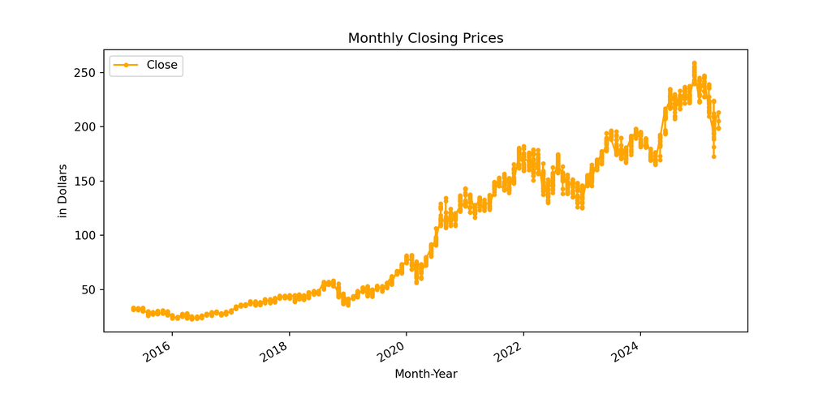

## Boxplot

```python
AAPL10.plot(column = ['Low', 'Close'],
kind='box',
by='Month',
figsize=(10, 5),
title='Distribution by Month',
layout=(2, 1));
```

## Boxplot graphic

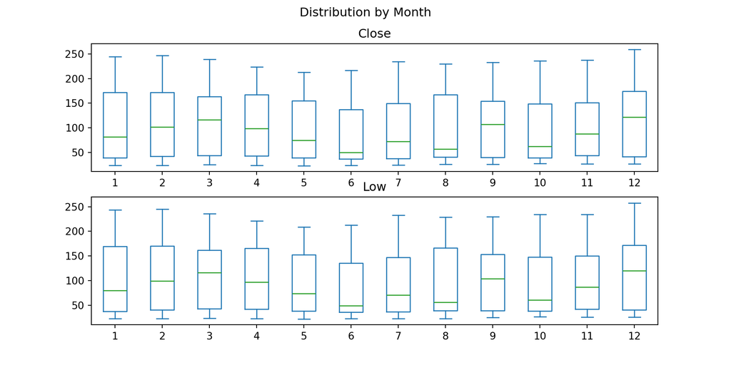

## Other possible uses

- calculate medians for each month using groupby

```python
# in one step
year_monthly_median_AAPL10 =  AAPL10.groupby(['Month'])[['Close', 'Low']].median().reset_index()

# in two steps, maybe more readable
## grouped = AAPL10.groupby(['Year', 'Month'])
## year_monthly_median_AAPL10 = grouped[['Close', 'Low']].median().reset_index()

print(year_monthly_median_AAPL10)
```

```
    Month      Close        Low
0       1   81.02625   80.01625
1       2  101.39500   99.61375
2       3  116.36000  116.21000
3       4   98.22500   97.28875
4       5   74.77375   74.16625
5       6   49.94250   49.71750
6       7   72.14375   70.98500
7       8   56.90750   56.50000
8       9  106.98000  104.05000
9      10   62.22625   61.20000
10     11   87.86500   86.89750
11     12  121.78000  120.15000
```

## Barplot of the medians

```python
year_monthly_median_AAPL10.plot.bar(x = 'Month',
y = 'Close',
rot=0,
color= 'tab:pink'); # from tableau
```

## Barplot of the medians

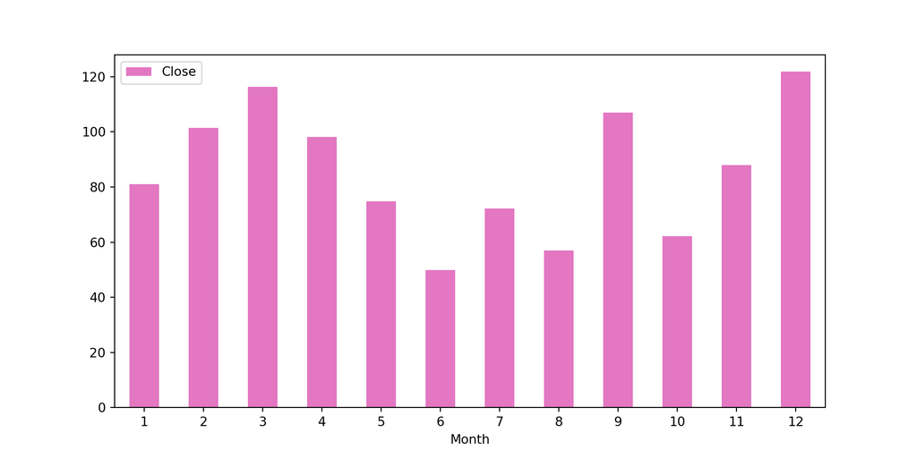

## Barplot Horizontal

```python
year_monthly_median_AAPL10.plot.barh(x = 'Month',
y = 'Close',
rot=0,
color= 'tab:pink'); # from tableau
```

## Barplot Horizontal

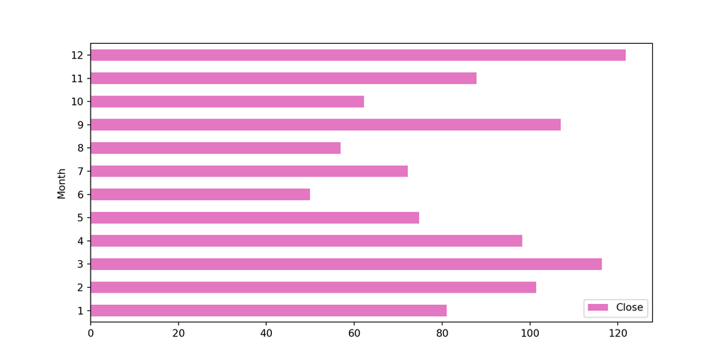

## We can pivot to wide

- The opposite of melt

```python
# Pivot table: average Close per Year-Month
pivot = AAPL10.pivot_table(values='Close', index='Year', columns='Month', aggfunc='median')
pivot = pivot.reindex(columns=range(1, 13))  # Ensure Jan-Dec order
```

```python
# Display
pivot.info()
```

```
<class 'pandas.core.frame.DataFrame'>
Index: 11 entries, 2015 to 2025
Data columns (total 12 columns):
 #   Column  Non-Null Count  Dtype
---  ------  --------------  -----
 0   1       10 non-null     float64
 1   2       10 non-null     float64
 2   3       10 non-null     float64
 3   4       10 non-null     float64
 4   5       11 non-null     float64
 5   6       10 non-null     float64
 6   7       10 non-null     float64
 7   8       10 non-null     float64
 8   9       10 non-null     float64
 9   10      10 non-null     float64
 10  11      10 non-null     float64
 11  12      10 non-null     float64
dtypes: float64(12)
memory usage: 1.1 KB
```

## called “calendar style”

```python
# Calendar style
pivot
```

```
Month         1         2          3   ...         10         11         12
Year                                   ...
2015         NaN       NaN        NaN  ...   27.95625   29.54125   27.72875
2016    24.34750   24.0450   26.22125  ...   29.07500   27.63000   28.95500
2017    29.96875   33.7550   34.99750  ...   39.08250   43.26750   42.84750
2018    43.58250   41.9450   43.82500  ...   55.16250   47.85250   41.37000
2019    38.45000   42.7650   46.53000  ...   58.96750   65.60500   69.86000
2020    78.17000   79.9025   63.63750  ...  116.24000  117.68500  127.23250
2021   131.01000  133.9400  121.39000  ...  144.84000  151.28000  174.82000
2022   172.08500  171.6600  163.98000  ...  143.86000  148.03000  136.50000
2023   135.24000  151.0100  155.00000  ...  174.33000  188.01000  193.93500
2024   185.92000  184.2600  172.45000  ...  230.57000  227.75000  248.13000
2025   236.42500  240.3600  220.84000  ...        NaN        NaN        NaN

[11 rows x 12 columns]
```

## pivot plotted

- usually used for heatmaps (next week)
- result on next slide

```python
pivot.plot(figsize=(10, 5),
legend=True,
title='AAPL Trends by Month & Year'); # note the semi-colon
```

## pivot plotted result

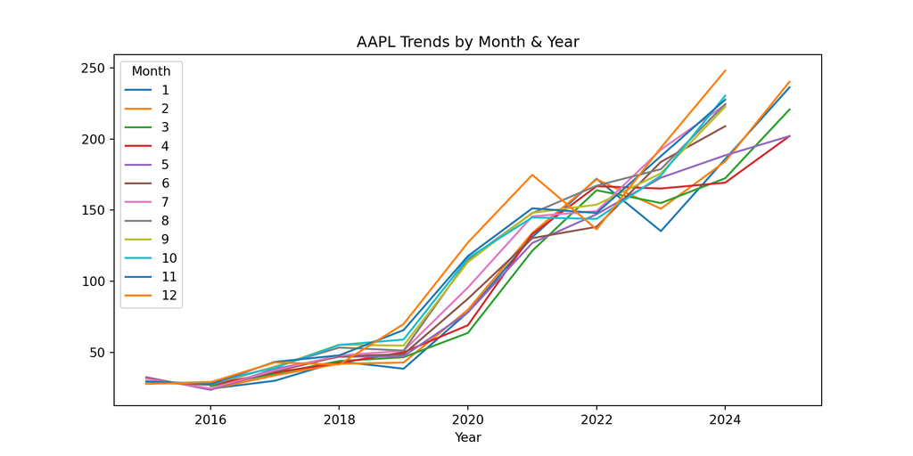

## pivot transposed then plotted

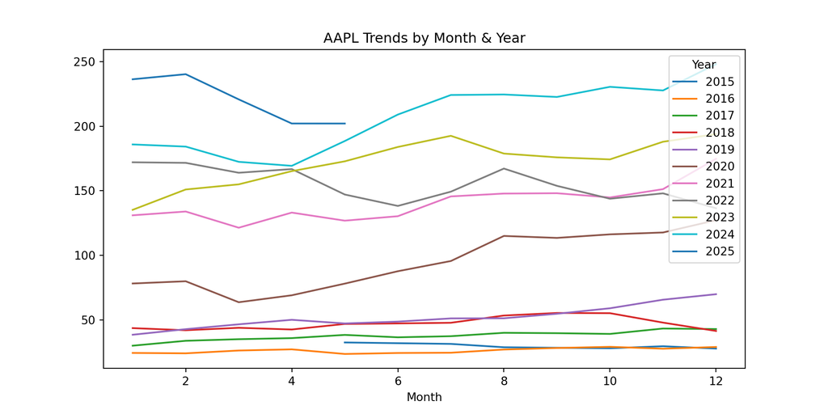

```python
pivot.T.plot(figsize=(10, 5), legend=True, title='AAPL Trends by Month & Year'); # note the semi-colon
```

## More Data

```python
import pandas as pd
SBUX10 = pd.read_csv("SBUX10.csv")

## create date/year/month variables as date time
SBUX10['Date'] = pd.to_datetime(SBUX10['Date'], format='%m/%d/%Y')
SBUX10['Year'] = SBUX10['Date'].dt.year
SBUX10['Month'] =SBUX10['Date'].dt.month

## fix the Close and Low variables variable
SBUX10[['Close', 'Low']] = SBUX10[['Close/Last', 'Low']].replace(r'[\$,]', '', regex=True).astype(float)

SBUX10 = SBUX10.drop(['Close/Last', 'Date'], axis = 1) # need to reassign
SBUX10.columns = ['SLow', 'SYear', 'SMonth', 'SClose']
print(SBUX10.head())
```

```
    SLow  SYear  SMonth  SClose
0  80.61   2025       5   82.78
1  81.59   2025       5   81.66
2  82.05   2025       5   84.69
3  80.27   2025       5   82.01
4  75.50   2025       4   80.05
```

## Put them together

```python
AAPL_SBUX = AAPL10.join(SBUX10,)
AAPL_SBUX.info()
```

[output not shown]

## Always check

```python
AAPL_SBUX.head()
```

```
          Low  Year  Month    Close       Date    SLow  SYear  SMonth  SClose
2514  31.0050  2015      5  31.3150 2015-05-01  48.720   2015       5   49.35
2499  32.4750  2015      5  32.5700 2015-05-01  51.450   2015       5   51.96
2500  32.7750  2015      5  32.9450 2015-05-01  51.445   2015       5   51.81
2501  32.5125  2015      5  33.0112 2015-05-01  50.910   2015       5   51.59
2502  32.2800  2015      5  32.4050 2015-05-01  50.660   2015       5   50.84
```

## Scatter

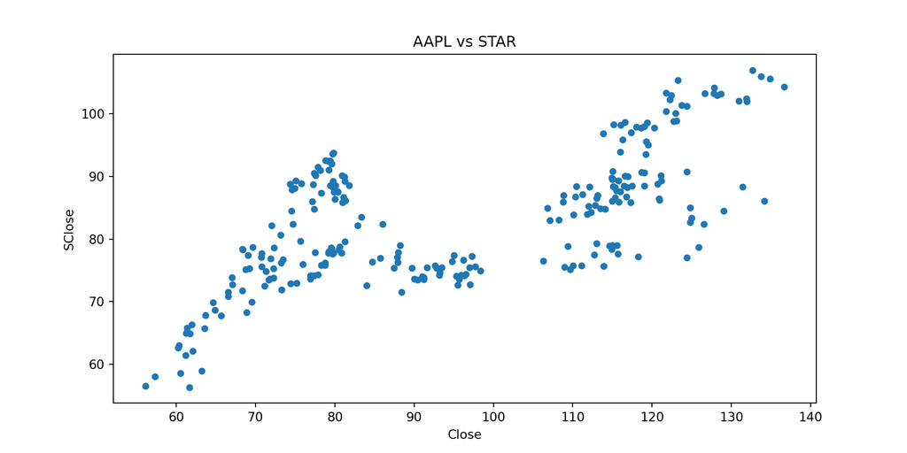

```python
AAPL_SBUX[AAPL_SBUX['SYear'] == 2020].plot(x = 'Close', y = 'SClose', kind = 'scatter', title = 'AAPL vs STAR');
```

## KDE

data[‘AAPL_Close’].plot(kind=‘kde’, bw_method=0.3)

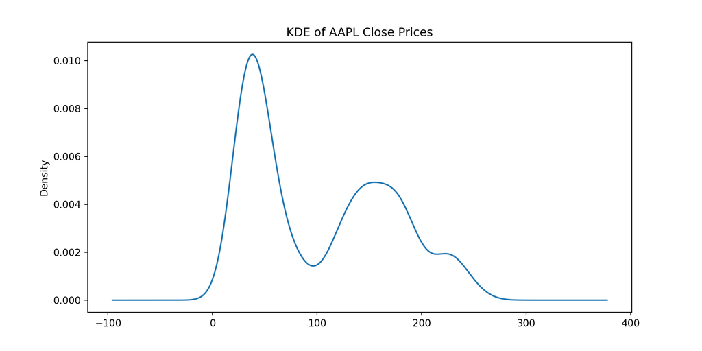

```python
AAPL_SBUX['Close'].plot(kind='kde', title='KDE of AAPL Close Prices')
```

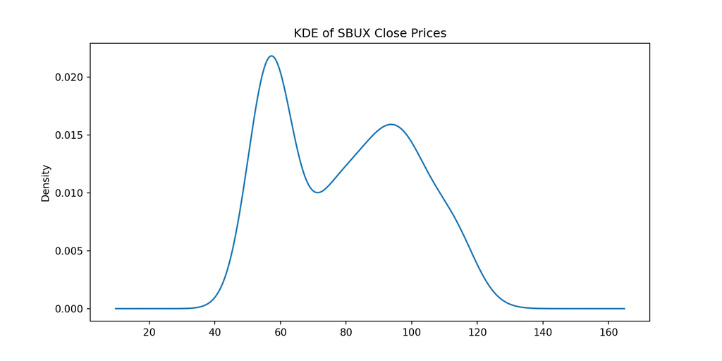

```python
AAPL_SBUX['SClose'].plot(kind='kde', bw_method=0.3, title='KDE of SBUX Close Prices')
```

## Last one

```python
import pandas as pd
import numpy as np
import matplotlib.pyplot as plt


# Create the plot
ax = AAPL_SBUX['SClose'].plot(
    kind='hist',
    bins=30,
    density=True,      # Normalize histogram to match KDE scale
    alpha=0.5,
    label='Histogram',
    figsize=(10, 5),
    title='SBUX Close Prices: Histogram + KDE'
)

# Overlay KDE on the same axes
AAPL_SBUX['SClose'].plot(
    kind='kde',
    ax=ax,
    label='KDE',
    linewidth=2
)

# Final touches
plt.xlabel('Price')
plt.ylabel('Density')
plt.legend()
plt.grid(True)
plt.tight_layout()
plt.show()
```

## result

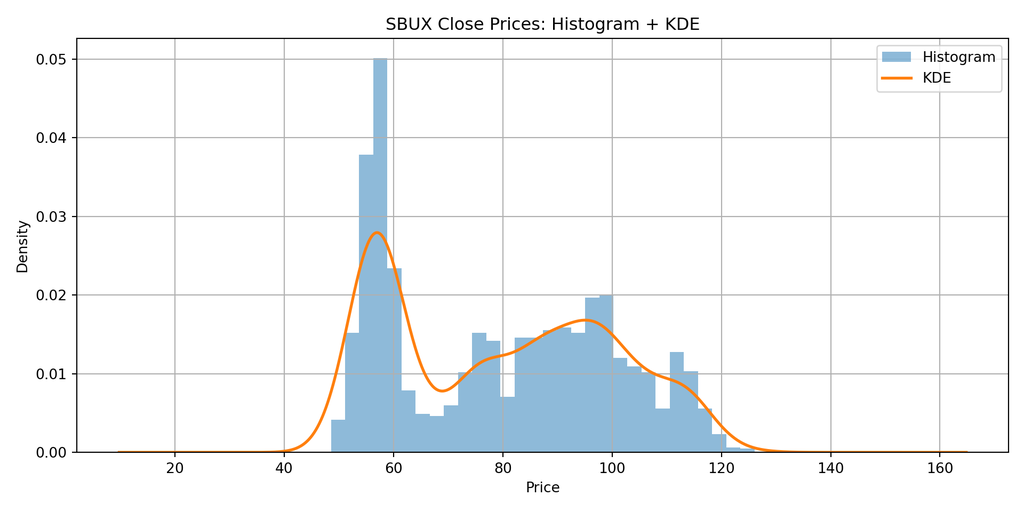

# matplotlib - the OG of Python Data Viz

## What is Matplotlib?

https://matplotlib.org/stable/api/pyplot_summary.html

- matplotlib was created in 2003 to serve as the plotting library for Python and for NumPy.
- Similar to MATLAB which widely used in math, CS and stat departments at the time.
- It is old, but worth your time because it is the foundation of graphics in Python and all related functions and their libraries are built on it.

https://github.com/matplotlib/matplotlib

**Note**

Always (community rules): `import matplotlib.pyplot as plt`

## Background

From their webpage:

Matplotlib is a comprehensive library for creating  
static,  
animated,  
and interactive visualizations in Python

- Matplotlib OO gives you control of an image from the most basic level, the pixel if you need it otherwise the figure and axes (plot)
- Matplotlib pyplot gives you provides convenient functions to make plotting easier

## Start it up

```python
import numpy as np
import pandas as pd
import matplotlib.pyplot as plt
import matplotlib.colors as mcolors

#%matplotlib inline #for you jupyter users
plt.rcParams['figure.figsize'] = [10, 5] # my default figure size for this lecture
plt.rcParams['figure.constrained_layout.use'] = True # supercedes tight layout
```

## Try it out

- you only need one set of values (implies y)
- x will be an index (0, 1, 2 etc.)
- see the next slide

```python
plt.plot([1, 2, 3])
plt.title("My First Plot")
```

## Try it out 2

- if it is not showing or if it is showing too much
- Try `%matplotlib inline` for the Jupyter users
- or add a semi-color or `plt.show()` to the end

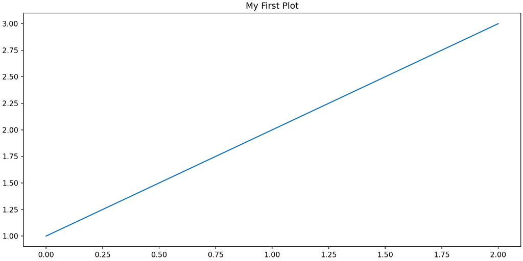

## What is pyplot?

- matplotlib.pyplot is a module (submodule) within the Matplotlib library
- it provides convenient functions for quickly building plots.
- it acts as a helper and manages figure creation, axes setup, and plot display automatically.
- doing this makes it easier for you to get figure on the screen
- it interfaces with the object-oriented API components of matplotlib’s object-oriented (OO) plotting system
- it is a good place to start

## plt.plot with x, y

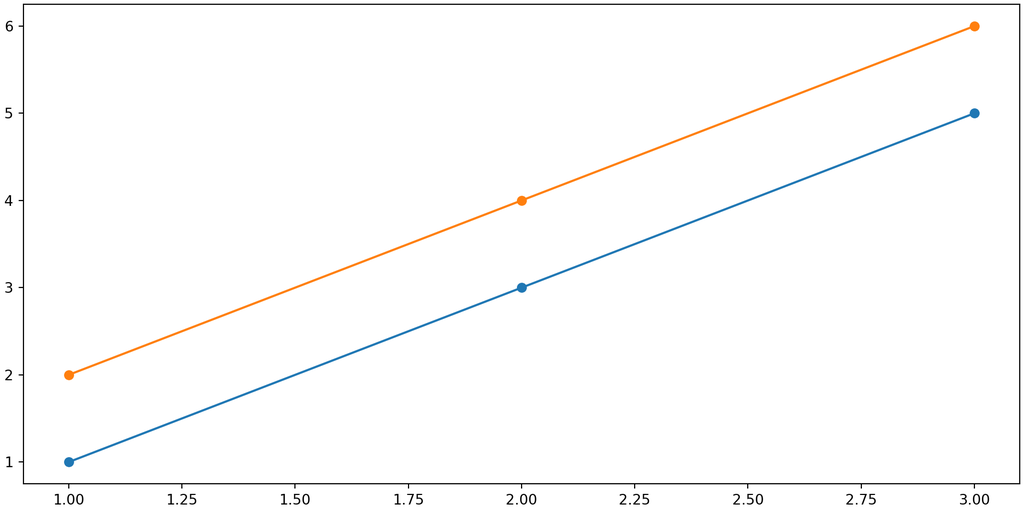

```python
x = [1, 2, 3]
y = np.array([[1, 2], [3, 4], [5, 6]])
plt.plot(x, y, 'o-') # [fmt] format
plt.show()
```

## plt.plot multiple

- pyplot adjust easily to your data (try this in R…)

```python
x1 = [1, 2, 3]
y1 = [1, 2, 3]
x2 = [4, 5, 6]
y2 = [4, 5, 8]
plt.plot(x1, y1, 'o-')
plt.plot(x2, y2, '+--')
plt.xlabel('x discontinuous')
plt.ylabel('y discontinuous')
plt.title('With multiple plots and x and y')
plt.show()
```

## plt.plot multiple result

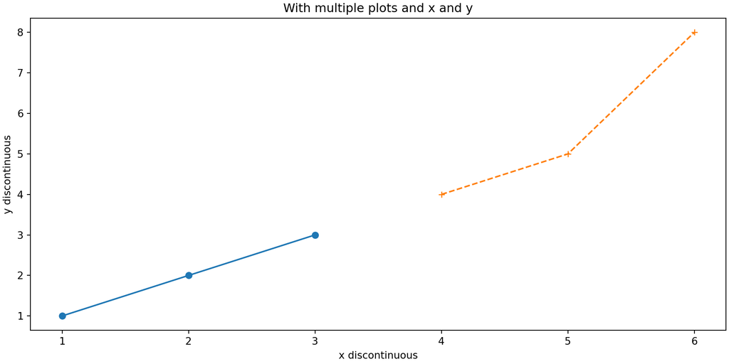

## Why plt.show() is needed sometimes

- In Quarto, a .py script or the REPL (like Python shell, or terminal), plots are not shown automatically
- In Jupyter notebooks plots display automatically
- plt.show() in a script Launches a window with the plot
- plt.show() may block further execution until the window is closed

## Saving plots

```python
x = [1, 2, 3]
y = np.array([[1, 2], [3, 4], [5, 6]])
plt.plot(x, y, 'o-')
plt.savefig("plot.png")
plt.show()  # to display
```

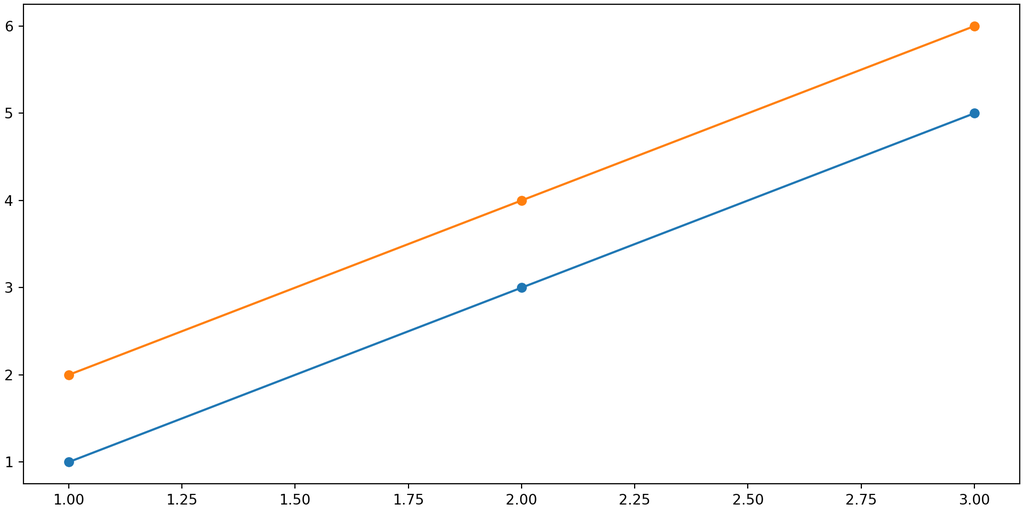

## Some formats and options

| Format | Extension(s) | Notes |
| --- | --- | --- |
| PNG | `.png` | Default |
| JPG | `.jpg`, `.jpeg` | Good for photos |
| PDF | `.pdf` | Best for print |
| SVG | `.svg` | Scalable vector good for web |

- dpi Dots per inch (resolution)
- Make background transparent with transparent=True

## Just enough functions

- Just enough to make you dangerous…

[output not shown]

# Activity and/or break

# Bridge to pandas

## Putting pandas to use

- Recall prep for analysis:

```python
import pandas as pd
AAPL10 = pd.read_csv("AAPL10.csv")

## create date/year/month variables as date time
AAPL10['Date'] = pd.to_datetime(AAPL10['Date'], format='%m/%d/%Y')
AAPL10['Year'] = AAPL10['Date'].dt.year
AAPL10['Month'] = AAPL10['Date'].dt.month

## fix the Close and Low variables variable
AAPL10[['Close', 'Low']] = AAPL10[['Close/Last', 'Low']].replace(r'[\$,]', '', regex=True).astype(float)

AAPL10 = AAPL10.drop(['Close/Last', 'Date'], axis = 1) # need to reassign

AAPL10['Date'] = pd.to_datetime(AAPL10[['Year', 'Month']].assign(DAY=1))  # Creates 2015-05-01 etc/

# Sort the data (important if it's not already sorted)
AAPL10 = AAPL10.sort_values('Date').reset_index(drop=True)
AAPL10.head()
```

## Result

```
       Low  Year  Month    Close       Date
0  31.0050  2015      5  31.3150 2015-05-01
1  32.4750  2015      5  32.5700 2015-05-01
2  32.7750  2015      5  32.9450 2015-05-01
3  32.5125  2015      5  33.0112 2015-05-01
4  32.2800  2015      5  32.4050 2015-05-01
```

## pandas pd.plot()

- The convenience wrapper on top of matplotlib

```python
AAPL10.plot(x='Date',
            y='Close',
            title='Monthly Closing Prices',
            xlabel = 'Month-Year',
            ylabel = 'in Dollars',
            marker=',',
            color = 'orange',
            figsize=(10, 5));
```

## pandas pd.plot() result

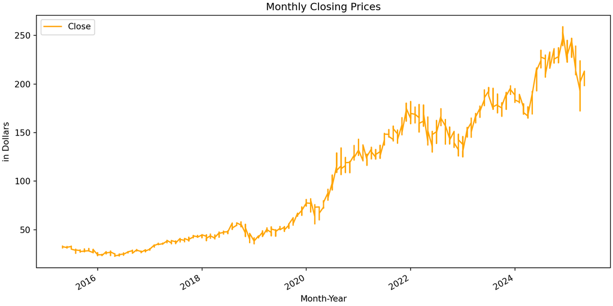

```python
AAPL10.plot(x='Date',
            y='Close',
            title='Monthly Closing Prices',
            xlabel = 'Month-Year',
            ylabel = 'in Dollars',
            marker=',',
            color = 'orange',
            figsize=(10, 5));
```

## pyplot equivalent

- matplotlib’s own convenience wrapper

```python
plt.plot(AAPL10['Date'], AAPL10['Close'], marker=',', color='orange')
plt.title('Monthly Closing Prices')
plt.xlabel('Month-Year')
plt.ylabel('in Dollars')
plt.show()
```

## pyplot result

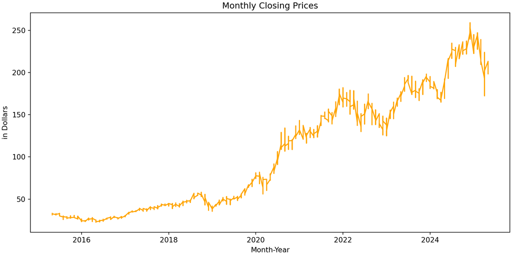

## matplotlib OOP equivalent

- plt.subplots gets us to figure and axes
- Here, we are creating a Figure or Axes object.
- In the previous slide everything is handled implicitly by pyplot.
- More time consuming to program but gives more control.

```python
import matplotlib.pyplot as plt

fig, ax = plt.subplots(figsize=(10, 5))
ax.plot(AAPL10['Date'],
        AAPL10['Close'],
        marker=',',
        color='orange')
ax.set_title('Monthly Closing Prices')
ax.set_xlabel('Month-Year')
ax.set_ylabel('in Dollars')
ax.figure;
```

## matplotlib OOP result

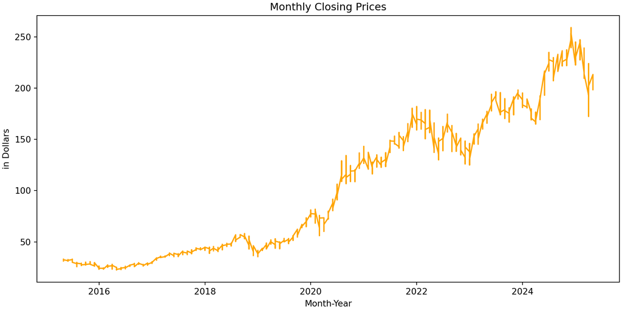

## What is Object Oriented matplotlib?

- it’s what you reach for when you want full control of a plot
- perhaps generating scientific figures
- perhaps working with images at the pixel level
- or you are customizing deeply

## Do you need the OOP access?

- The best use is when you must create reusable and/or complex plots
- A complex plot may involve multiple subplots
- If you are doing quick things for homework or for an EDA accessing graphics through pandas is perfectly fine
- If your plans take you into production work, then lean towards OOP

## pandas → matplotlib → seaborn/plotly

Think of pandas pd.plot() as the gateway to more advanced tools:

1. Start with df.plot() because you have pandas skills
2. Work with matplotlib for customization and layout
3. Move onto seaborn and others for higher-level statistical plots (thease are just wrappers like pandas pd.plot)

## Integration with NumPy, SciPy, and beyond

Because matplotlib is built to work seamlessly with NumPy arrays, it extends to:

- Scientific data (signal processing, simulations, statistics)
- Machine learning model outputs
- Matrices, vectors, and function plots
- Computer vision etc.

## Why invest the time?

Even at a basic level, learning matplotlib gives you:

- The confidence to fix or enhance any pandas (or other wrapper) plot
- Access to advanced plots not possible in pandas
- The ability to communicate data insights more professionally

## What can we customize?

- Font sizes and styles
- Tick marks and labels
- Colors, transparency, line thickness, point shapes
- Axis scaling and limits
- Custom annotations (arrows, text, highlights)
- Multi-panel layouts
- Export quality (for publications, posters, etc.)

Most anything generated by matplotlib can be customized

## some basics not available in pandas

- matplotlib.pyplot has many functions
- these are not available in pandas

| Function | Notes |
| --- | --- |
| plt.errorbar() | Scientific data with uncertainty |
| plt.imshow() | Image data, heatmaps |
| plt.contour() | 3D-like contour plots |
| plt.quiver() | Vector fields (e.g., wind, direction) |
| plt.polar() | Polar plots (e.g., angles, radar) |

## The anatomy of a matplotlib figure

https://matplotlib.org/stable/gallery/showcase/anatomy.html

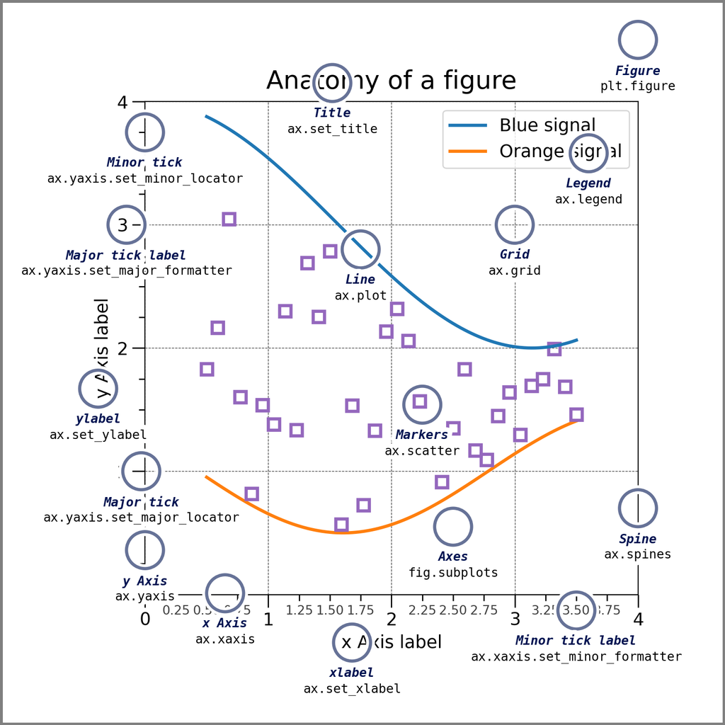

## Working with pyplot

Some resources

- pyplot overview: https://matplotlib.org/stable/api/pyplot_summary.html
- plot: https://matplotlib.org/stable/api/_as_gen/matplotlib.pyplot.plot.html